# Correlaciones

Edimer David Jaramillo

3 de agosto de 2019

# Base de datos

```r
datos <- read.csv("Datos_Continentes.csv")
datos
```

| pais | cajeros17 | camas14 | cto_pib16 | densidad17 | desempleo17 | deuda16 | electri16 | fertil16 | gasto_edu16 | gasto_id16 | gasto_militar17 | pib16 | pm2517 | pobRural17 | tierrasCult16 | continente |
| --- | --- | --- | --- | --- | --- | --- | --- | --- | --- | --- | --- | --- | --- | --- | --- | --- |
| Afganistán | 1.274667 | 0.50 | 2.2603142 | 5.442221e+01 | 1.559 | NA | 84.137138 | 1.218230e+01 | 4.20525 | NA | 9.068569e-01 | 1.904636e+10 | 56.910808 | 74.750 | 11.83867904 | Asia |
| Albania | 31.471579 | NA | 3.3500000 | 1.048707e+02 | 13.750 | NA | 100.000000 | 1.261385e+02 | 3.95464 | NA | 1.244175e+00 | 1.188368e+10 | 18.200603 | 40.617 | 22.63868569 | Europa |
| Alemania | NA | NA | 2.2422351 | 2.366780e+02 | 3.746 | 2.93949 | 100.000000 | 1.972283e+02 | NA | 2.93949 | 1.220136e+00 | 3.495163e+12 | 12.028767 | 22.739 | 33.67013968 | Europa |
| Andorra | NA | NA | 1.8891244 | 1.637553e+02 | NA | NA | 100.000000 | NA | 3.25670 | NA | NA | 2.877312e+09 | 10.307621 | 11.850 | 1.65957441 | Europa |
| Angola | NA | NA | -2.5800972 | 2.389043e+01 | 7.139 | NA | 40.520607 | 7.982743e+00 | NA | NA | 2.201338e+00 | 1.011239e+11 | 32.388505 | 35.161 | 3.93037619 | Africa |
| Antigua y Barbuda | 63.114237 | 3.80 | 5.5897391 | 2.318455e+02 | NA | NA | 97.354668 | 1.387000e+01 | NA | NA | NA | 1.464630e+09 | 18.622343 | 75.287 | 9.09090909 | América |
| Arabia Saudita | 74.375035 | 2.70 | 1.6706423 | 1.532231e+01 | 5.890 | NA | 100.000000 | 1.768737e+02 | NA | NA | 1.028867e+01 | 6.449355e+11 | 87.945447 | 16.378 | 1.61744251 | Asia |
| Argelia | 9.384573 | NA | 3.3000000 | 1.734788e+01 | 11.996 | NA | 99.439568 | 2.231527e+01 | NA | NA | 5.708235e+00 | 1.601299e+11 | 38.884011 | 27.948 | 3.10873571 | Africa |
| Argentina | 59.391257 | 5.00 | -1.8225422 | 1.617686e+01 | 8.347 | 0.53274 | 100.000000 | 5.033633e+01 | 5.57218 | 0.53274 | 9.096630e-01 | 5.548609e+11 | 13.311834 | 8.251 | 14.32387300 | América |
| Armenia | 63.690056 | NA | 0.2000000 | 1.029312e+02 | 17.827 | 0.23305 | 100.000000 | 1.104951e+02 | 2.75812 | 0.23305 | 3.968039e+00 | 1.054614e+10 | 32.528118 | 36.897 | 15.67966259 | Asia |

[output cut: 204 more lines]

# Resumen numérico

El resumen numérico de las variables cuantitativas tiene los siguientes estadísticos:

- Media
- Mediana
- Desviación estándar
- Mínimo
- Máximo

## Tabla por defecto

```r
# Bibliotecas
library(tidyr)
library(dplyr)

# Resumen numérico por variable
datos %>%
  select(-c(pais, continente)) %>%
  gather(key = "variable", value = "valor") %>%
  group_by(variable) %>%
  summarise(Promedio = mean(valor, na.rm = TRUE),
            DE = sd(valor, na.rm = TRUE),
            Min = min(valor, na.rm = TRUE),
            Max = max(valor, na.rm = TRUE),
            Mediana = median(valor, na.rm = TRUE))
```

| variable | Promedio | DE | Min | Max | Mediana |
| --- | --- | --- | --- | --- | --- |
| cajeros17 | 5.511960e+01 | 4.692907e+01 | 1.274667e+00 | 3.131528e+02 | 4.576590e+01 |
| camas14 | 2.291633e+00 | 1.571654e+00 | 5.000000e-01 | 6.200000e+00 | 1.600000e+00 |
| cto_pib16 | 3.026401e+00 | 3.751874e+00 | -1.362146e+01 | 2.822384e+01 | 3.062600e+00 |
| densidad17 | 4.493870e+02 | 2.051630e+03 | 1.368522e-01 | 2.047918e+04 | 9.467309e+01 |
| desempleo17 | 7.358919e+00 | 5.532971e+00 | 1.400000e-01 | 2.744400e+01 | 5.760000e+00 |
| deuda16 | 1.034774e+00 | 1.023584e+00 | 1.498000e-02 | 4.251210e+00 | 6.541850e-01 |
| electri16 | 8.435029e+01 | 2.638333e+01 | 7.588477e+00 | 1.000000e+02 | 1.000000e+02 |
| fertil16 | 4.176058e+02 | 2.442772e+03 | 4.020905e-01 | 3.023786e+04 | 1.193096e+02 |
| gasto_edu16 | 4.530416e+00 | 1.534184e+00 | 1.371020e+00 | 1.029313e+01 | 4.440990e+00 |
| gasto_id16 | 1.034774e+00 | 1.023584e+00 | 1.498000e-02 | 4.251210e+00 | 6.541850e-01 |

[output cut: 5 more lines]

## Tabla con DT

```r
# Bibliotecas
library(DT)

# Resumen numérico por variable
datos %>%
  select(-c(pais, continente)) %>%
  gather(key = "variable", value = "valor") %>%
  group_by(variable) %>%
  summarise(Promedio = mean(valor, na.rm = TRUE),
            DE = sd(valor, na.rm = TRUE),
            Min = min(valor, na.rm = TRUE),
            Max = max(valor, na.rm = TRUE),
            Mediana = median(valor, na.rm = TRUE)) %>%
  datatable()
```

|  | variable | Promedio | DE | Min | Max | Mediana |
| --- | --- | --- | --- | --- | --- | --- |
| 1 | cajeros17 | 55.1196036377194 | 46.9290679842077 | 1.27466705619395 | 313.152787448703 | 45.7658986412207 |
| 2 | camas14 | 2.29163265306122 | 1.57165431279005 | 0.5 | 6.2 | 1.6 |
| 3 | cto_pib16 | 3.02640099479596 | 3.75187392717875 | -13.621458438417 | 28.2238442822384 | 3.06260036695409 |
| 4 | densidad17 | 449.387043752041 | 2051.62952192389 | 0.136852235351444 | 20479.1778885587 | 94.6730948993107 |
| 5 | desempleo17 | 7.35891895640541 | 5.53297052970703 | 0.140000000596046 | 27.4440002441406 | 5.76000022888184 |
| 6 | deuda16 | 1.03477384615385 | 1.02358403615596 | 0.01498 | 4.25121 | 0.654185 |
| 7 | electri16 | 84.3502905575734 | 26.38333302863 | 7.58847713470459 | 100 | 100 |
| 8 | fertil16 | 417.605786272689 | 2442.77179288074 | 0.402090467725481 | 30237.8556190309 | 119.309633027523 |
| 9 | gasto_edu16 | 4.53041608612259 | 1.53418432589205 | 1.37101995944977 | 10.2931299209595 | 4.44098997116089 |
| 10 | gasto_id16 | 1.03477384615385 | 1.02358403615596 | 0.01498 | 4.25121 | 0.654185 |

[output cut: 5 more lines]

## Tabla con Knitr

```r
# Bibliotecas
library(knitr)

# Resumen numérico por variable
datos %>%
  select(-c(pais, continente)) %>%
  gather(key = "variable", value = "valor") %>%
  group_by(variable) %>%
  summarise(Promedio = mean(valor, na.rm = TRUE),
            DE = sd(valor, na.rm = TRUE),
            Min = min(valor, na.rm = TRUE),
            Max = max(valor, na.rm = TRUE),
            Mediana = median(valor, na.rm = TRUE)) %>%
  kable()
```

| variable | Promedio | DE | Min | Max | Mediana |
| --- | --- | --- | --- | --- | --- |
| cajeros17 | 5.511960e+01 | 4.692907e+01 | 1.274667e+00 | 3.131528e+02 | 4.576590e+01 |
| camas14 | 2.291633e+00 | 1.571654e+00 | 5.000000e-01 | 6.200000e+00 | 1.600000e+00 |
| cto_pib16 | 3.026401e+00 | 3.751874e+00 | -1.362146e+01 | 2.822384e+01 | 3.062600e+00 |
| densidad17 | 4.493870e+02 | 2.051630e+03 | 1.368522e-01 | 2.047918e+04 | 9.467309e+01 |
| desempleo17 | 7.358919e+00 | 5.532971e+00 | 1.400000e-01 | 2.744400e+01 | 5.760000e+00 |
| deuda16 | 1.034774e+00 | 1.023584e+00 | 1.498000e-02 | 4.251210e+00 | 6.541850e-01 |
| electri16 | 8.435029e+01 | 2.638333e+01 | 7.588477e+00 | 1.000000e+02 | 1.000000e+02 |
| fertil16 | 4.176058e+02 | 2.442772e+03 | 4.020905e-01 | 3.023786e+04 | 1.193096e+02 |
| gasto_edu16 | 4.530416e+00 | 1.534184e+00 | 1.371020e+00 | 1.029313e+01 | 4.440990e+00 |
| gasto_id16 | 1.034774e+00 | 1.023584e+00 | 1.498000e-02 | 4.251210e+00 | 6.541850e-01 |
| gasto_militar17 | 1.863974e+00 | 1.615046e+00 | 0.000000e+00 | 1.207272e+01 | 1.436931e+00 |
| pib16 | 3.788623e+11 | 1.633312e+12 | 3.657261e+07 | 1.870719e+13 | 2.695857e+10 |
| pm2517 | 2.695940e+01 | 1.882999e+01 | 5.861331e+00 | 9.973437e+01 | 2.156899e+01 |
| pobRural17 | 3.901814e+01 | 2.382689e+01 | 0.000000e+00 | 8.729400e+01 | 3.826900e+01 |
| tierrasCult16 | 1.417527e+01 | 1.349633e+01 | 8.628130e-02 | 5.964669e+01 | 1.042367e+01 |

## Descripción del proceso

- El proceso anterior se puede describir de la siguiente manera:
  1. `Datos` es la base de datos sobre la cual deseo ejecutar un proceso.
  2. `%>%` operador de tubería que se lee como “*entonces*”“. Permite que el código sea legible, además, proporciona operaciones en cadena.
  3. **Opcional:** como la descripción numérica que se va a realizar sólo es con las variables cuantitativas, selecciono unicamente aquellas de interés, es decir, todas excepto el país y el contienente (por ser texto o factores).
  4. La función `gather()` permite pasar de múltiples columnas a dos variables que contienen la misma información. Los argumentos necesarios para procesar son:
     - `key`: nombre de la nueva variable que contiene los encabezados (nombres de variables en la base de datos con formato ancho).
     - `value`: nombre de la nueva variable que contiene valores asociados a las variables de interés.
  5. La función `group_by()` permitirá agrupar por `variable`, es decir, que en teoría se tendrán 15 grupos (porque son 15 variables).
  6. La función `summarise()` permite generar resúmenes numéricos en función de la agrupación previa. Los nombres `Promedio`, `DE`, `Min`, `Max` y `Mediana` los asigna el usuario.
  7. **Nota:** el argumento `na.rm = TRUE` en las funciones de estadísticos descriptivos permite remover los `NAs` para efectuar el cálculo.

# Gráficos de dispersión

## Gráfio X vs Y (simple)

- **Gráfico con todos los datos:**

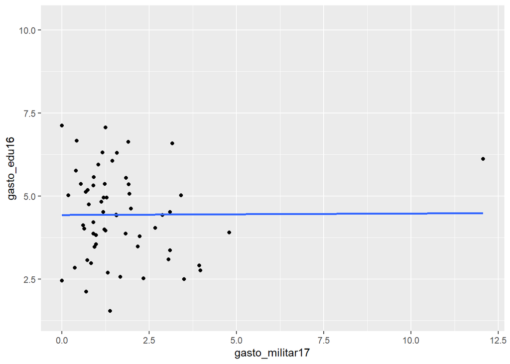

```r
# Biblioteca
library(ggplot2)

# Gráfico
ggplot(data = datos, mapping = aes(x = gasto_militar17, y = gasto_edu16)) +
  geom_point() +
  geom_smooth(method = "lm", se = FALSE)
```

- **Gráfico con filtro sobre dato “atípico” en gasto militar:**

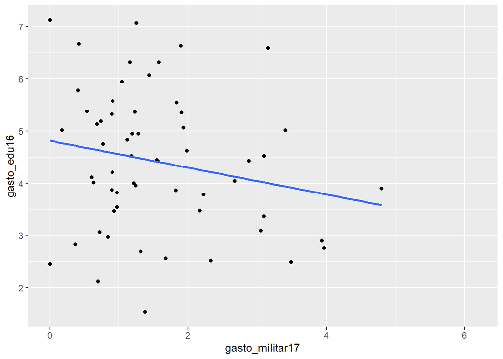

```r
# Gráfico
datos %>%
  filter(gasto_militar17 <= 10) %>%
  ggplot(data = ., mapping = aes(x = gasto_militar17, y = gasto_edu16)) +
  geom_point() +
  geom_smooth(method = "lm", se = FALSE)
```

## Matriz Dispersión 1

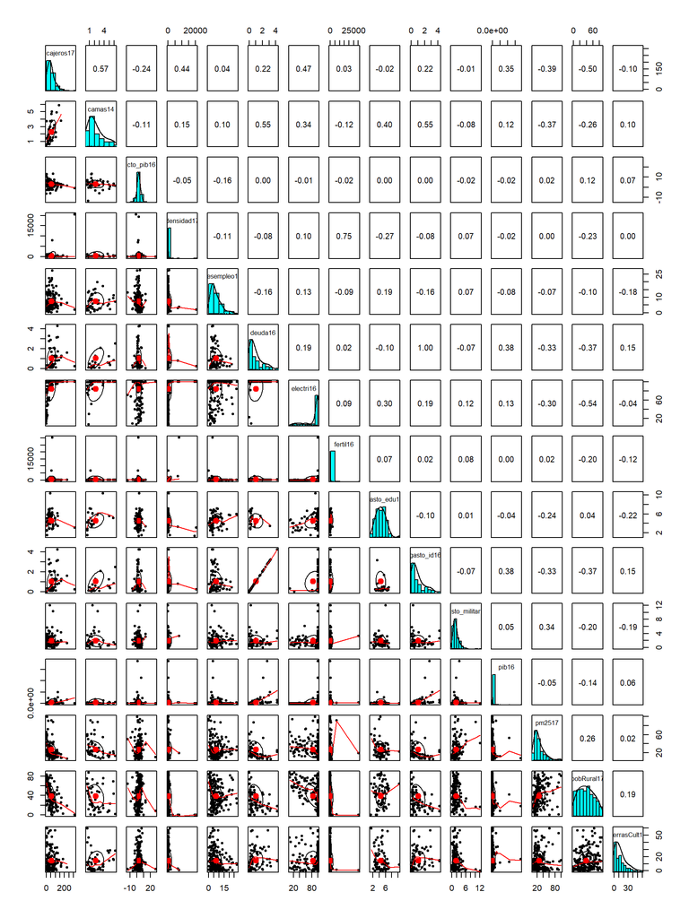

```r
# Biblioteca
library(psych)

# Matriz de dispersión
datos_disp <- datos %>%
  select_if(is.numeric)

pairs.panels(datos_disp)
```

- **Matriz de dispersión reducida (ejemplo):**

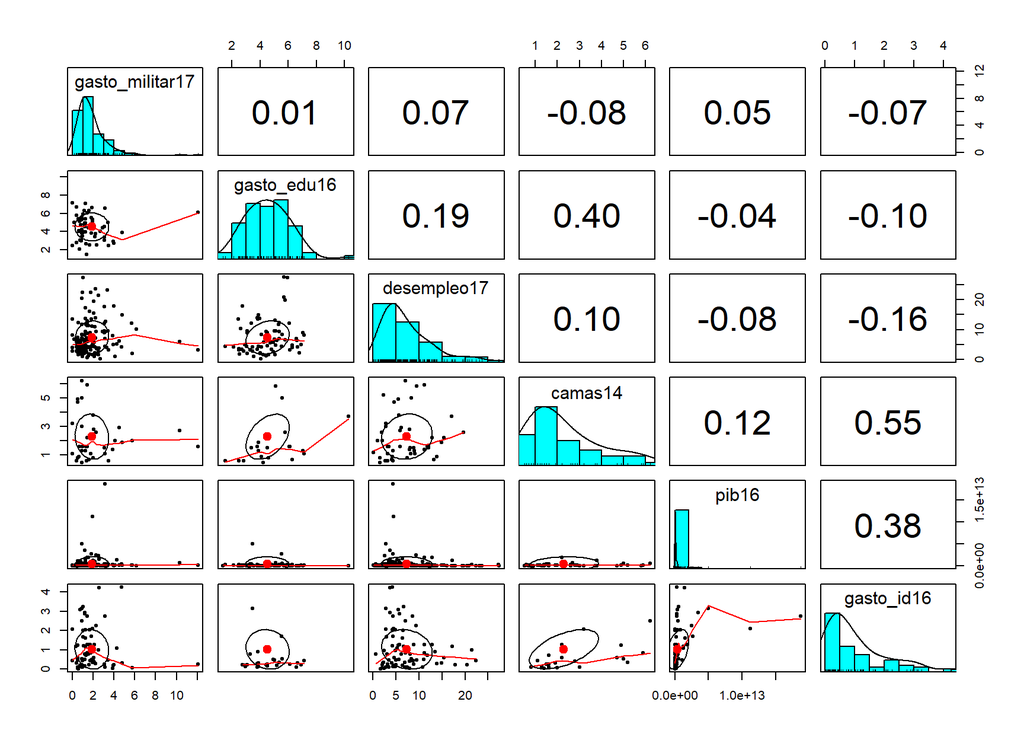

```r
datos_disp2 <- datos %>%
  select(gasto_militar17, gasto_edu16, desempleo17,
         camas14, pib16, gasto_id16)

pairs.panels(datos_disp2)
```

## Matriz de dispersión `ggplot2`

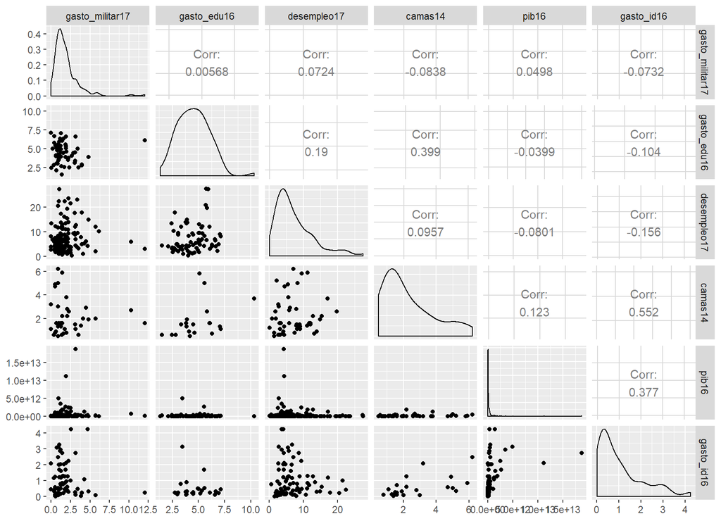

```r
# Biblioteca
library(GGally)

# Matriz de dispersión
ggpairs(datos_disp2)
```

## Matriz de correlaciones numérica

```r
# Obtener correlaciones (Pearson: ejemplo)
matriz_cor <- cor(datos_disp2, use = "pairwise.complete.obs")
matriz_cor
```

```
##                 gasto_militar17  gasto_edu16 desempleo17     camas14
## gasto_militar17     1.000000000  0.005680844  0.07243089 -0.08380492
## gasto_edu16         0.005680844  1.000000000  0.18996210  0.39890799
## desempleo17         0.072430891  0.189962103  1.00000000  0.09568141
## camas14            -0.083804924  0.398907991  0.09568141  1.00000000
## pib16               0.049793587 -0.039946838 -0.08014070  0.12298349
## gasto_id16         -0.073199552 -0.103750960 -0.15564109  0.55237344
##                       pib16  gasto_id16
## gasto_militar17  0.04979359 -0.07319955
## gasto_edu16     -0.03994684 -0.10375096
## desempleo17     -0.08014070 -0.15564109
## camas14          0.12298349  0.55237344
## pib16            1.00000000  0.37707683
## gasto_id16       0.37707683  1.00000000
```

## Matriz de correlaciones gráfica

- **Método por defecto:**

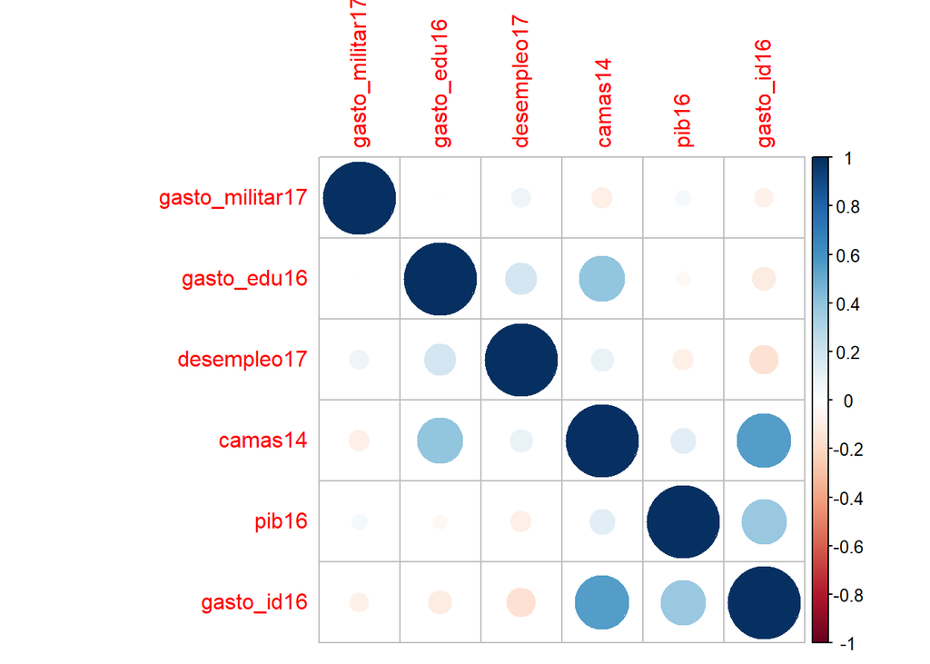

```r
# Biblioteca
library(corrplot)

# Gráfico
corrplot(matriz_cor)
```

- **Otro método gráfico:**

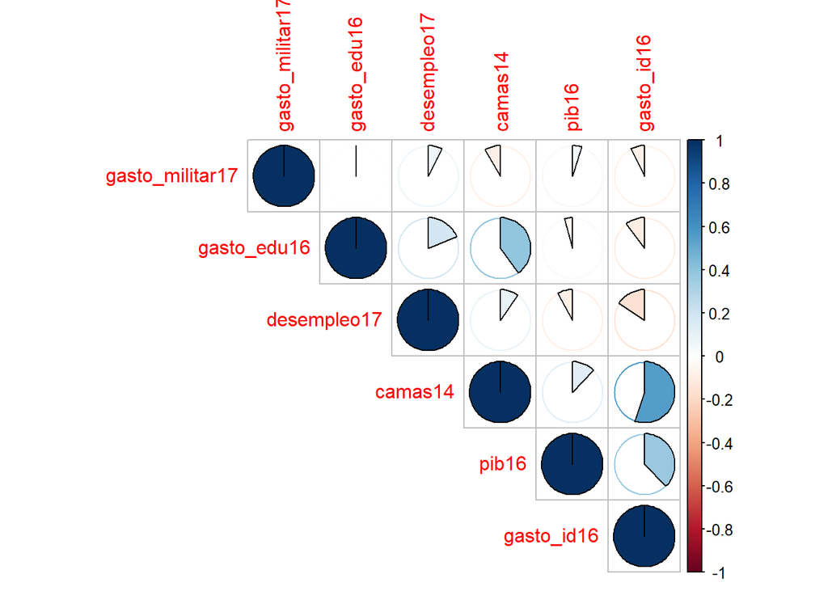

```r
corrplot(matriz_cor, method = "pie", type = "upper")
```

- **Otro gráfico sin la diagonal:**

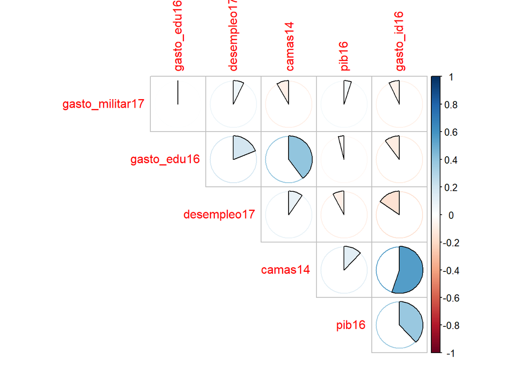

```r
corrplot(matriz_cor, method = "pie", type = "upper",
         diag = FALSE)
```

- **Matriz de correlación completa - método “color”:**

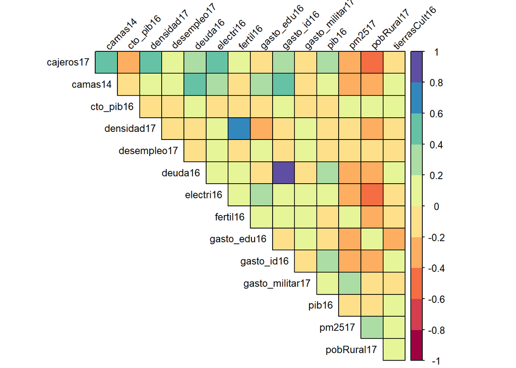

```r
matriz_cor2 <- cor(datos_disp,
                   use = "pairwise.complete.obs",
                   method = "pearson")
library(RColorBrewer)
corrplot(matriz_cor2, type = "upper", diag = FALSE,
         method = "color", addgrid.col = "black",
         tl.col = "black", tl.srt = 45, tl.cex = 0.8,
         col = brewer.pal(name = "Spectral", n = 10))
```